# Predicting cell state from signaling activity

Author

Evert Bosdriesz

## Background

Cell state markers are defined as antibodies that show no differential expression upon either treatment. We’ve clustered cells based on cell state markers. A heatmap of the resulting clustering indicates that the signaling markers, which were not used in determining the clusters, nonetheless showed clear cell state specific expression patterns. This raises the question to which extend cell state information is present in the signaling state. To study this question, we will train cell state classifiers using the signaling state markers as features. We assess the performance of the classifiers using 5-fold cross-validation.

## Loading and exploring the data

```r
dat_zscore <- read_csv(
  here("data", "processed" ,"TMM_normalised_z_transformed_concencus_clusters.csv"),
  show_col_types = FALSE) |>
  select(-...1, -plate_number) |> # Keep treatment and sample ID
  mutate(
    cluster = as_factor(cluster),
    treatment = as_factor(treatment))

cell_state_markers <- read_lines(here("data", "annotations", "cell_state_markers.txt"))
signaling_state_markers <- read_lines(here("data", "annotations", "signalling_state_markers.txt"))
```

## Overview of the data

```r
sampleSize <- data.frame(matrix(nrow = 0, ncol = 2))
colnames(sampleSize) <- c("Cluster", "Size")
for(i in seq(1:9))
{
  sampleSize[nrow(sampleSize) + 1,] = c(i, nrow(dat_zscore[dat_zscore$cluster == i,]))
}
knitr::kable(sampleSize)
```

| Cluster | Size |
| --- | --- |
| 1 | 54 |
| 2 | 90 |
| 3 | 63 |
| 4 | 45 |
| 5 | 62 |
| 6 | 58 |
| 7 | 84 |
| 8 | 57 |
| 9 | 33 |

## Training the model

We will train two types of models. Predicting the cell state from the cell state markers (as a positive control) and predicting it from the signaling state markers **that were not used in defining the cell state*.

```r
dat_cellstate <- select(dat_zscore, all_of(c("cluster", "sample_id",
                                             "treatment", cell_state_markers)))
dat_sigstate <- select(dat_zscore, all_of(c("cluster", "sample_id",
                                            "treatment", signaling_state_markers)))
```

We will use

- Multinomal logistic regression
- Random forrest
- Graph Convolutional Neural Network (GCNN) (output generated in python notebook)

We are running a 5-fold (inner & outer) nested cross-validation with 5 repeats. For the random forest we trained the hyperparameters mtry, min_n, trees with 3 parameter options for each in the inner fold. For the MLR model we optimized the penalty and model-type (mixture) in a randomly initialized grid with 50 combinations.

### Random forest

```r
#Inspecting accuracy for single parameter changes

data_sig <- dat_sigstate %>% select(-c("sample_id", "treatment"))
fold <- vfold_cv(data_sig, repeats = 5, strata = cluster)
#INFLUENCE OF MIN_N
parameters <- c(2, 5, 10, 15, 20)
inspect_single_parameter(parameters, fold, "min_n")
#INFLUENCE OF MTRY
parameters <- c(2, 5, 10, 15, 20)
inspect_single_parameter(parameters, fold, "mtry")
#INFLUENCE OF TREE NUMBER
parameters <- c(50, 100, 500, 1000, 2000, 4000)
inspect_single_parameter(parameters, fold, "trees")
```

As a baseline model we predict the cluster from the cell state markers - which were used to define the clusters; How well can we predict the cell state from the cell state markers? As expected, quite well.

This results in in an average accuracy of 83 and ROC AUC of 98 for the baseline model predicting cell state from cell state markers. For predicting the cell state from signaling markers we achieve an accuracy of 52 and ROC AUC of 87.

```
[1] "The average accuracy is 0.826478147974738"
[1] "The average ROC AUC is 0.983195339833658"
```

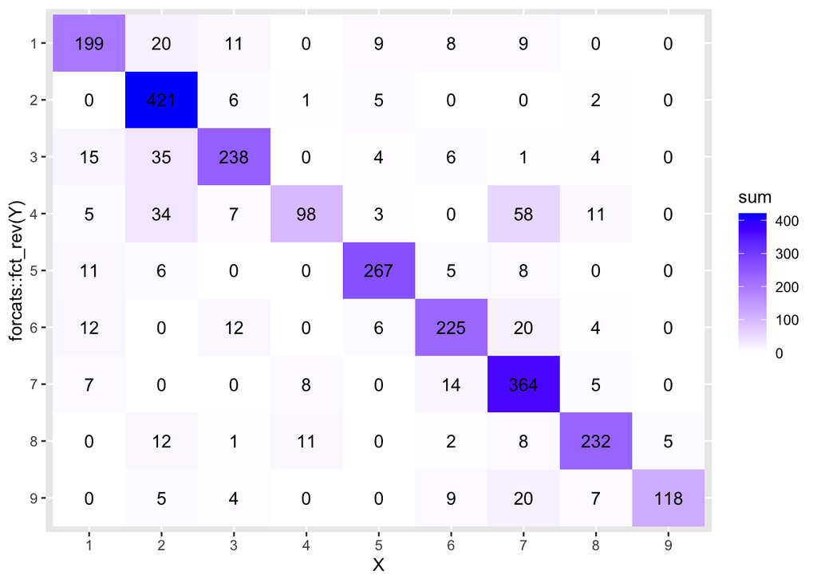

```r
#parameters
hyperparams <- expand.grid(min_n = c(2, 5,10), mtry = c(2, 5,10), trees = c(500, 1000, 2000))

#data_cell <- dat_cellstate %>% select(-c("sample_id", "treatment"))
#estimates_cellstate_rf <- predict_performance(data_cell, rf_mod_grid_search, hyperparams, repeats = 5)
#save(estimates_cellstate_rf, file = here("data", "cellstate-prediction", "Results_CellState_RF.RData"))
estimates_cellstate_rf <- get(load(here("data", "cellstate-prediction", "Results_CellState_RF.RData")))

#data_sig <- dat_sigstate %>% select(-c("sample_id", "treatment"))
#estimates_sigstate_rf <- predict_performance(data_sig, rf_mod_grid_search, hyperparams, repeats = 5)
#save(estimates_sigstate_rf, file = here("data", "cellstate-prediction", "Results_SigState_RF.RData"))
estimates_sigstate_rf <- get(load(here("data", "cellstate-prediction", "Results_SigState_RF.RData")))

# Visualizations of results
visualize_performance(estimates_cellstate_rf)
```

```
[1] "The average accuracy is 0.520361499268623"
[1] "The average ROC AUC is 0.874482237886671"
```

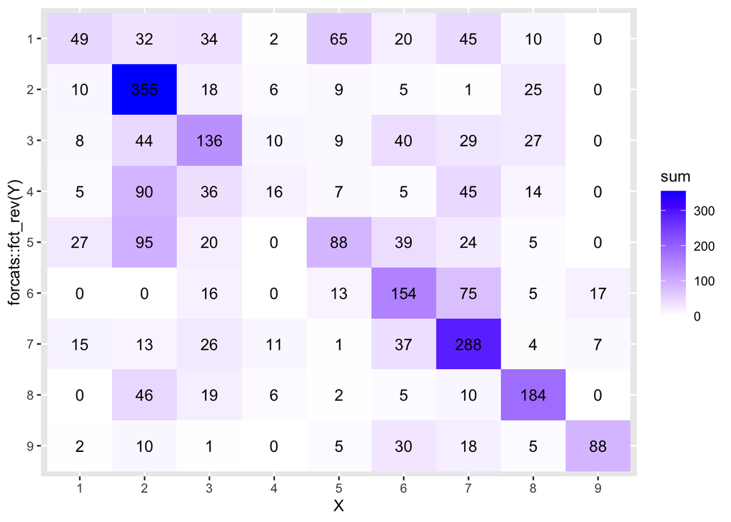

```r
visualize_performance(estimates_sigstate_rf)
```

Following plots show examplary ROC-CURVES for the 9 differences classes for the first outer-fold of the baseline (cell state) and signaling state model:

```r
print("Cell State Marker Prediction")
```

```
[1] "Cell State Marker Prediction"
```

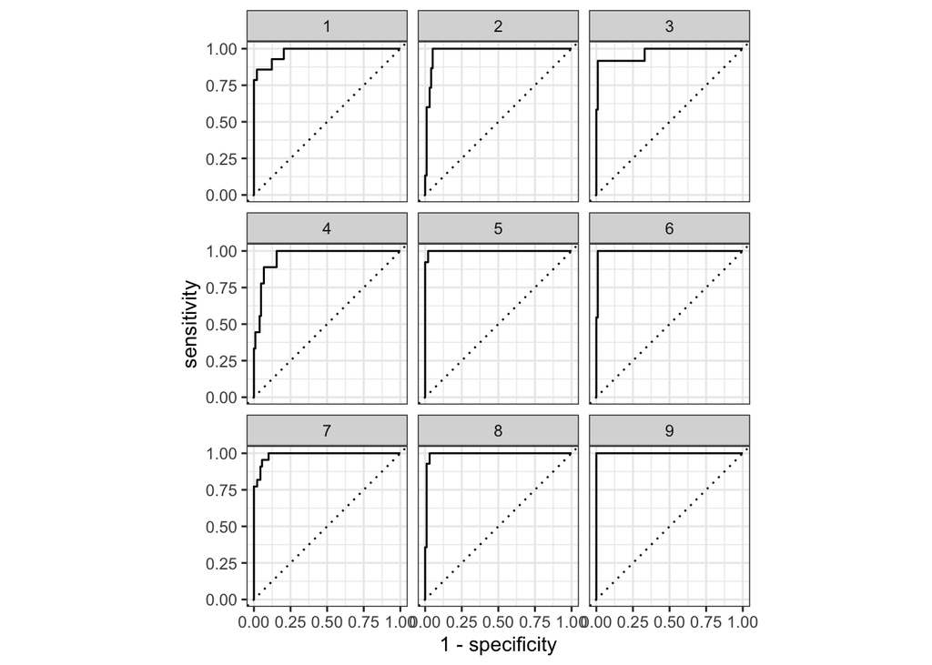

```r
estimates_cellstate_rf[[1]]$ROC_CURVE
```

```r
print("Signaling State Marker Prediction")
```

```
[1] "Signaling State Marker Prediction"
```

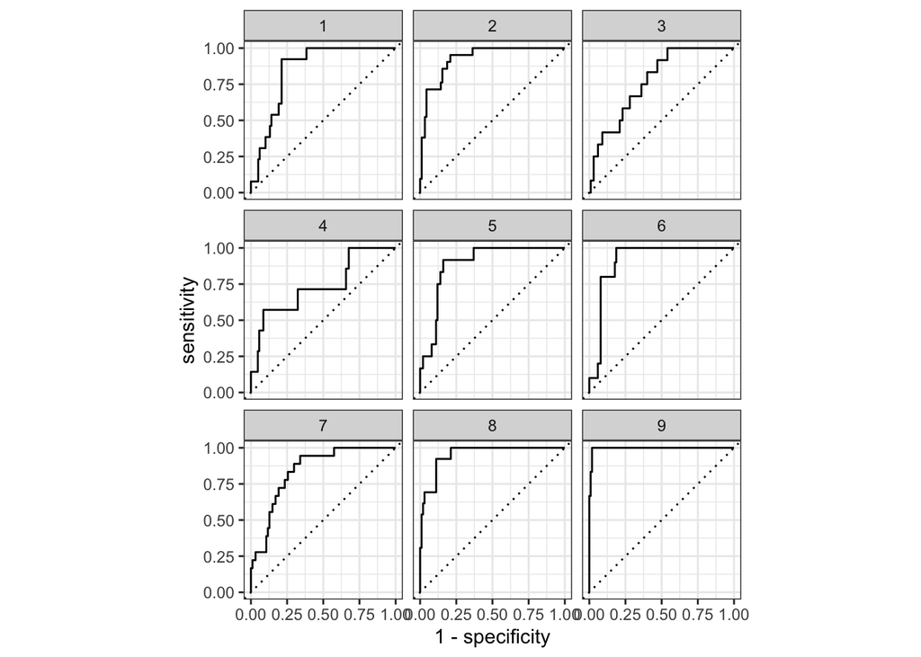

```r
estimates_sigstate_rf[[1]]$ROC_CURVE
```

These results seem consistent with Klaas’ analysis.

### Multinomial logistic regression

For Multinomial logistic regression we tune mixture (model type) together with the penalty over a semi-random grid with 50 combinations.

```
[1] "The average accuracy is 0.540166239822493"
[1] "The average ROC AUC is 0.880890769538267"
```

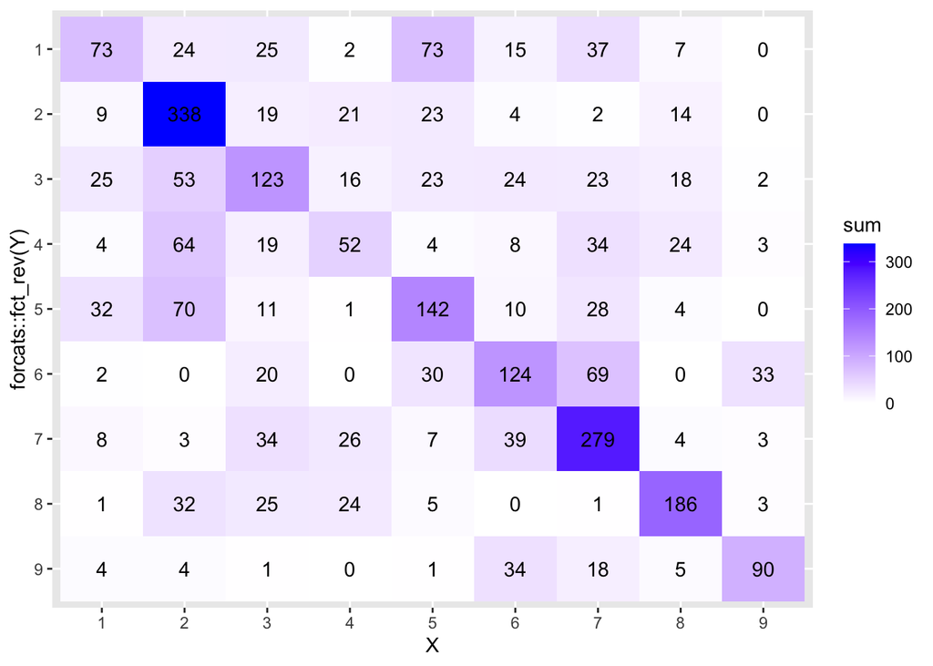

```r
#MLR
hyperparams <- 50
#data_sig <- dat_sigstate %>% select(-c("sample_id", "treatment"))
#estimates_sigstate_mlr <- predict_performance(data_sig, mlr_mod, hyperparams, repeats = 5)
#save(estimates_sigstate_mlr, file = here("data", "cellstate-prediction", "Results_SigState_MLR.RData"))
estimates_sigstate_mlr <- get(load(here("data", "cellstate-prediction", "Results_SigState_MLR.RData")))

visualize_performance(estimates_sigstate_mlr)
```

### SVM

```
[1] "The average accuracy is 0.510765574005421"
[1] "The average ROC AUC is 0.772578549369267"
```

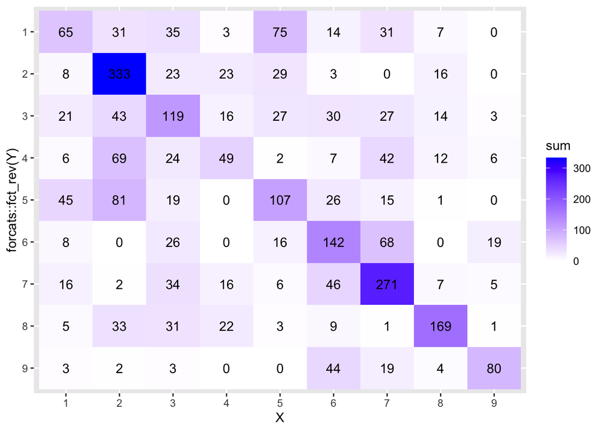

```r
#SVM
#hyperparams <- 50
#data_sig <- dat_sigstate %>% select(-c("sample_id", "treatment"))
#estimates_sigstate_svm <- predict_performance(data_sig, svm_mod, hyperparams, repeats = 5)
#save(estimates_sigstate_svm, file = here("data", "cellstate-prediction", "Results_SigState_SVM.RData"))
estimates_sigstate_svm <- get(load(here("data", "cellstate-prediction", "Results_SigState_SVM.RData")))

visualize_performance(estimates_sigstate_svm)
```